# StoutQ1

Name: Adeep Avinash Kulkarni Question: Stout Case Study Q1 Position: Data and Digital Analytics Intern

Let’s import the dataset first and store it into a data frame

```r
library(tidyverse)
loan_data <- read_csv('/Users/adeepkulkarni/Downloads/loans_full_schema.csv')
str(loan_data)
```

```
## spec_tbl_df [10,000 × 55] (S3: spec_tbl_df/tbl_df/tbl/data.frame)
##  $ emp_title                       : chr [1:10000] "global config engineer" "warehouse office clerk" "assembly" "customer service" ...
##  $ emp_length                      : num [1:10000] 3 10 3 1 10 NA 10 10 10 3 ...
##  $ state                           : chr [1:10000] "NJ" "HI" "WI" "PA" ...
##  $ homeownership                   : chr [1:10000] "MORTGAGE" "RENT" "RENT" "RENT" ...
##  $ annual_income                   : num [1:10000] 90000 40000 40000 30000 35000 34000 35000 110000 65000 30000 ...
##  $ verified_income                 : chr [1:10000] "Verified" "Not Verified" "Source Verified" "Not Verified" ...
##  $ debt_to_income                  : num [1:10000] 18.01 5.04 21.15 10.16 57.96 ...
##  $ annual_income_joint             : num [1:10000] NA NA NA NA 57000 NA 155000 NA NA NA ...
##  $ verification_income_joint       : chr [1:10000] NA NA NA NA ...
##  $ debt_to_income_joint            : num [1:10000] NA NA NA NA 37.7 ...
##  $ delinq_2y                       : num [1:10000] 0 0 0 0 0 1 0 1 1 0 ...
##  $ months_since_last_delinq        : num [1:10000] 38 NA 28 NA NA 3 NA 19 18 NA ...
##  $ earliest_credit_line            : num [1:10000] 2001 1996 2006 2007 2008 ...
##  $ inquiries_last_12m              : num [1:10000] 6 1 4 0 7 6 1 1 3 0 ...
##  $ total_credit_lines              : num [1:10000] 28 30 31 4 22 32 12 30 35 9 ...
##  $ open_credit_lines               : num [1:10000] 10 14 10 4 16 12 10 15 21 6 ...
##  $ total_credit_limit              : num [1:10000] 70795 28800 24193 25400 69839 ...
##  $ total_credit_utilized           : num [1:10000] 38767 4321 16000 4997 52722 ...
##  $ num_collections_last_12m        : num [1:10000] 0 0 0 0 0 0 0 0 0 0 ...
##  $ num_historical_failed_to_pay    : num [1:10000] 0 1 0 1 0 0 0 0 0 0 ...
##  $ months_since_90d_late           : num [1:10000] 38 NA 28 NA NA 60 NA 71 18 NA ...
##  $ current_accounts_delinq         : num [1:10000] 0 0 0 0 0 0 0 0 0 0 ...
##  $ total_collection_amount_ever    : num [1:10000] 1250 0 432 0 0 0 0 0 0 0 ...
##  $ current_installment_accounts    : num [1:10000] 2 0 1 1 1 0 2 2 6 1 ...
##  $ accounts_opened_24m             : num [1:10000] 5 11 13 1 6 2 1 4 10 5 ...
##  $ months_since_last_credit_inquiry: num [1:10000] 5 8 7 15 4 5 9 7 4 17 ...
##  $ num_satisfactory_accounts       : num [1:10000] 10 14 10 4 16 12 10 15 21 6 ...
##  $ num_accounts_120d_past_due      : num [1:10000] 0 0 0 0 0 0 0 NA 0 0 ...
##  $ num_accounts_30d_past_due       : num [1:10000] 0 0 0 0 0 0 0 0 0 0 ...
##  $ num_active_debit_accounts       : num [1:10000] 2 3 3 2 10 1 3 5 11 3 ...
##  $ total_debit_limit               : num [1:10000] 11100 16500 4300 19400 32700 ...
##  $ num_total_cc_accounts           : num [1:10000] 14 24 14 3 20 27 8 16 19 7 ...
##  $ num_open_cc_accounts            : num [1:10000] 8 14 8 3 15 12 7 12 14 5 ...
##  $ num_cc_carrying_balance         : num [1:10000] 6 4 6 2 13 5 6 10 14 3 ...
##  $ num_mort_accounts               : num [1:10000] 1 0 0 0 0 3 2 7 2 0 ...
##  $ account_never_delinq_percent    : num [1:10000] 92.9 100 93.5 100 100 78.1 100 93 97.1 100 ...
##  $ tax_liens                       : num [1:10000] 0 0 0 1 0 0 0 0 0 0 ...
##  $ public_record_bankrupt          : num [1:10000] 0 1 0 0 0 0 0 0 0 0 ...
##  $ loan_purpose                    : chr [1:10000] "moving" "debt_consolidation" "other" "debt_consolidation" ...
```

[output cut: 60 more lines]

```
##   ..   interest_rate = col_double(),
##   ..   installment = col_double(),
##   ..   grade = col_character(),
##   ..   sub_grade = col_character(),
##   ..   issue_month = col_character(),
##   ..   loan_status = col_character(),
##   ..   initial_listing_status = col_character(),
##   ..   disbursement_method = col_character(),
##   ..   balance = col_double(),
##   ..   paid_total = col_double(),
##   ..   paid_principal = col_double(),
##   ..   paid_interest = col_double(),
##   ..   paid_late_fees = col_double()
##   .. )
##  - attr(*, "problems")=<externalptr>
```

Let’s check the first six elements of the dataframe using the head() function

```r
head(loan_data)
```

```
## # A tibble: 6 × 55
##   emp_title              emp_length state homeownership annual_income verified_income
##   <chr>                       <dbl> <chr> <chr>                 <dbl> <chr>
## 1 global config engineer          3 NJ    MORTGAGE              90000 Verified
## 2 warehouse office clerk         10 HI    RENT                  40000 Not Verified
## 3 assembly                        3 WI    RENT                  40000 Source Verified
## 4 customer service                1 PA    RENT                  30000 Not Verified
## 5 security supervisor            10 CA    RENT                  35000 Verified
## 6 <NA>                           NA KY    OWN                   34000 Not Verified
## # … with 49 more variables: debt_to_income <dbl>, annual_income_joint <dbl>,
## #   verification_income_joint <chr>, debt_to_income_joint <dbl>,
## #   delinq_2y <dbl>, months_since_last_delinq <dbl>,
## #   earliest_credit_line <dbl>, inquiries_last_12m <dbl>,
## #   total_credit_lines <dbl>, open_credit_lines <dbl>,
## #   total_credit_limit <dbl>, total_credit_utilized <dbl>,
## #   num_collections_last_12m <dbl>, num_historical_failed_to_pay <dbl>, …
```

Basically, the dataset represents set of elements and entries of every loan made from one entity to another. The data that exists is about information about the loans and the entities themselves.

Problem with the dataset is that there are too many null values and missing data but since the number of entries is relatively high it should not cause a huge issue with the analysis of said loan data.

Let’s start with creating five visualizations of this data.

Before we do however, we need to export few libraries we will be using for the visualization and the prediction models.

```r
library(ggplot2)
library(ggmap)
library(readr)
library(tidyr)
library(readr)
```

Let’s start the first visualization by understanding what the map function does.

We will do a visualization to check the number of loans accepted per US state on this map of the United States

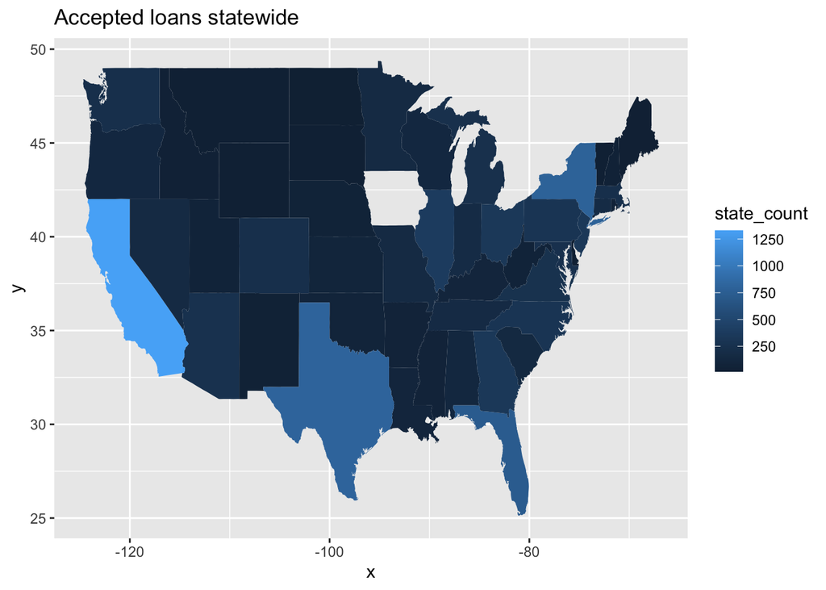

```r
usa_map <- map_data("state")
loan_data %>% mutate(state_name=state.name[match(state,state.abb)]) %>% mutate(state_name=str_to_lower(state_name)) %>% filter(is.na(state_name)==FALSE) %>% group_by(state_name) %>% mutate(state_count = n()) %>% select(state_name,state_count) %>% unique() %>% ggplot() + geom_map(map = usa_map, aes(map_id = state_name, fill = state_count)) +
  expand_limits(x = usa_map$long, y = usa_map$lat) +
  labs(title = "Accepted loans statewide")
```

As we can see from the map, the most loans are in California, Texas and New York states.

To confirm let’s also do a comparative bar plot of the states data

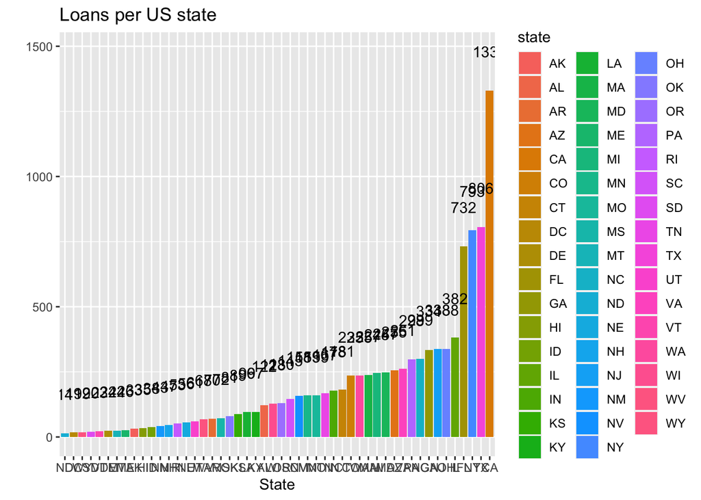

```r
loan_data %>%
  group_by(state) %>%
  mutate(state_count = n()) %>%
  select(state,state_count) %>%
  unique() %>%
  ggplot(aes(x = fct_reorder(state, state_count), y = state_count, fill = state, label = state_count)) +
  geom_col() +
  geom_text(nudge_y = 150) +
  labs(x = "State", y = "", title = "Loans per US state")
```

While we are on the topic of bar plots, let’s do one for loan purpose

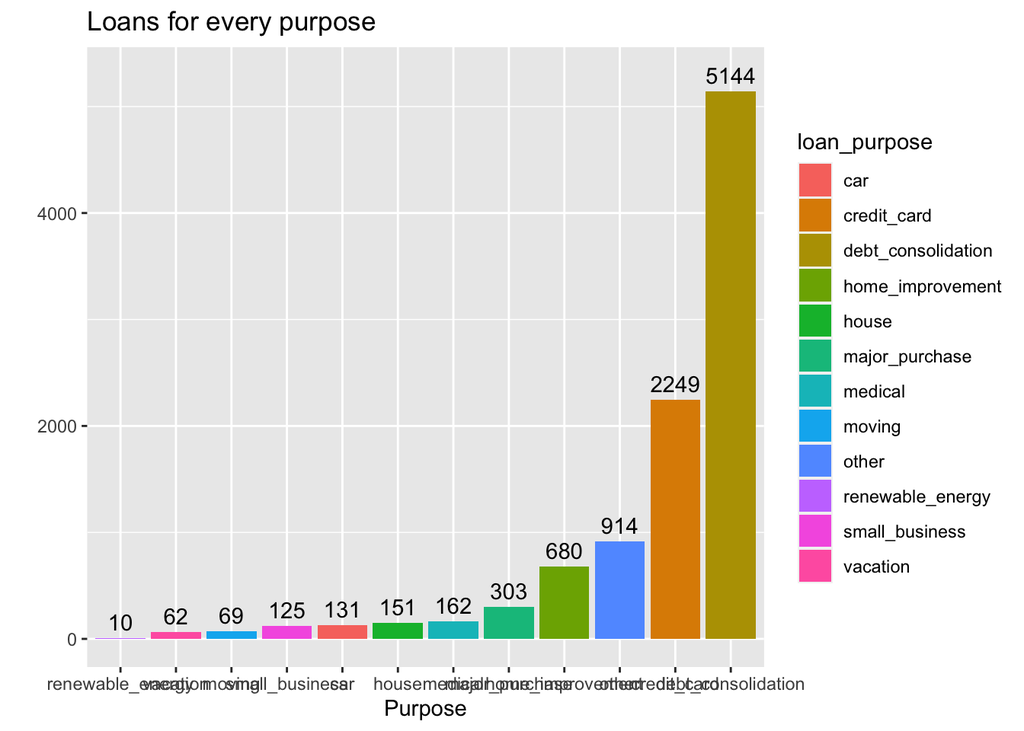

```r
loan_data %>%
  group_by(loan_purpose) %>%
  mutate(loan_purpose_count = n()) %>%
  select(loan_purpose,loan_purpose_count) %>%
  unique() %>%
  ggplot(aes(x = fct_reorder(loan_purpose,loan_purpose_count), y = loan_purpose_count, fill = loan_purpose, label = loan_purpose_count)) +
  geom_col() +
  geom_text(nudge_y = 150) +
  labs(x = "Purpose", y = "", title = "Loans for every purpose")
```

From the diagram we can make out that loans are most used for debt consolidation and paying off credit card bills

Now we will plot a boxplot with regard to loan grade in the loan data

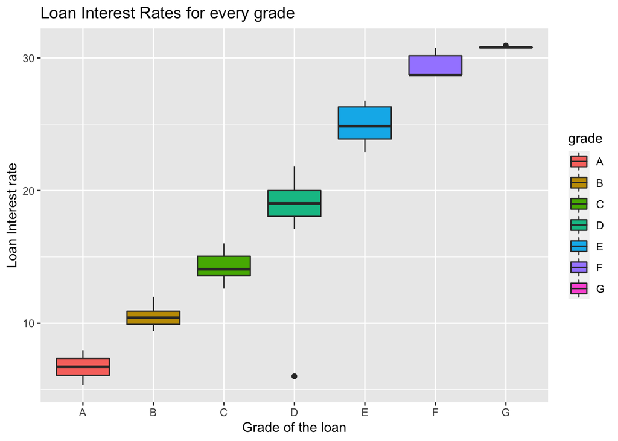

```r
loan_data %>% ggplot(aes(x = grade, y = interest_rate, fill = grade)) + geom_boxplot() +
  labs(x = "Grade of the loan", y = "Loan Interest rate", title = "Loan Interest Rates for every grade")
```

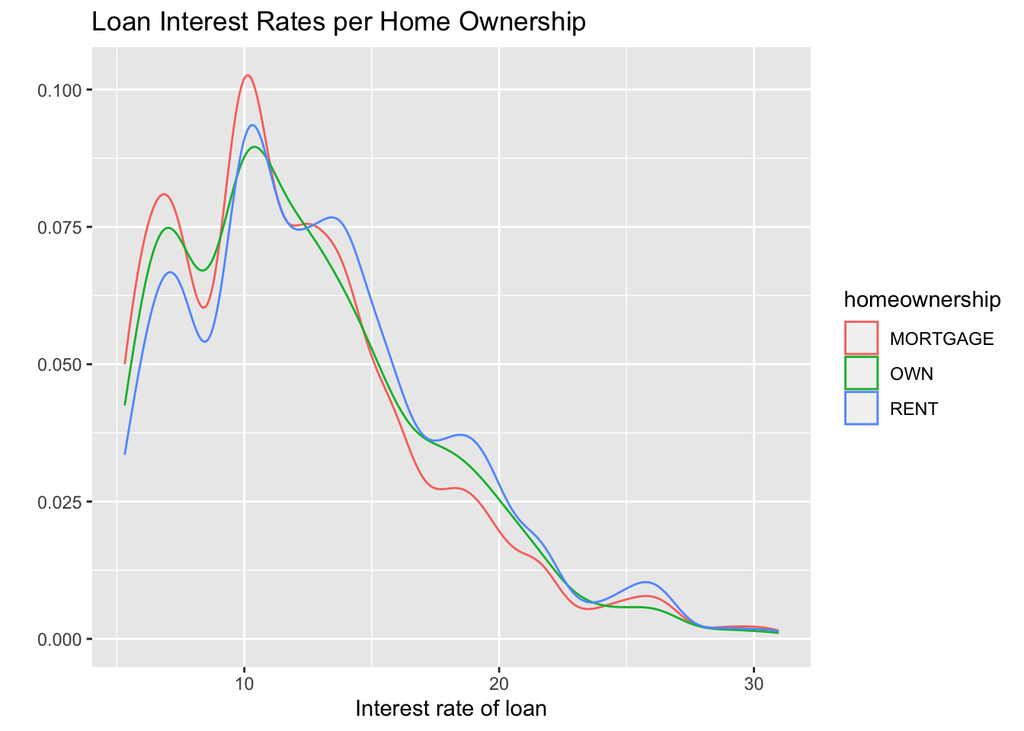

```r
loan_data %>%
  ggplot(aes(x = interest_rate, color = homeownership)) +
  geom_density() +
  labs(x = "Interest rate of loan", y = "", title = "Loan Interest Rates per Home Ownership")
```

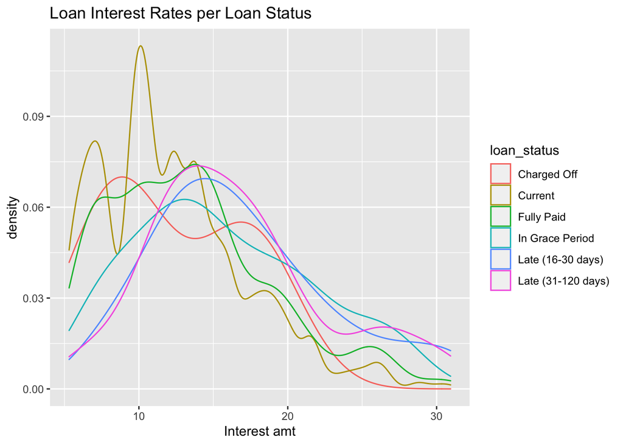

```r
loan_data %>%
  ggplot(aes(x = loan_data$interest_rate, color = loan_status)) +
  geom_density() +
  labs(x = "Interest amt", title = "Loan Interest Rates per Loan Status")
```

We drew 2 density plots of loan status v loan home ownership record with respect to its interest rate.

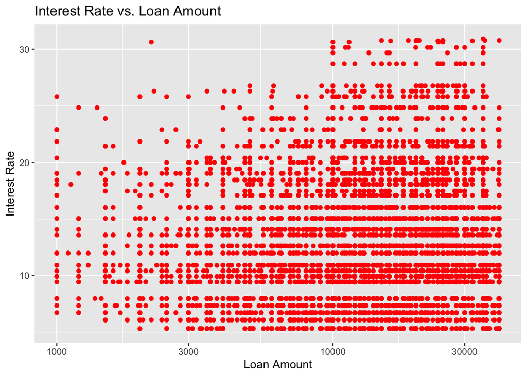

```r
loan_data %>% filter(loan_amount > 8) %>% ggplot(aes(x = loan_amount, y = interest_rate)) +geom_point(color = "red") +
  scale_x_log10() +
  labs(x = "Loan Amount", y = "Interest Rate", title = "Interest Rate vs. Loan Amount")
```

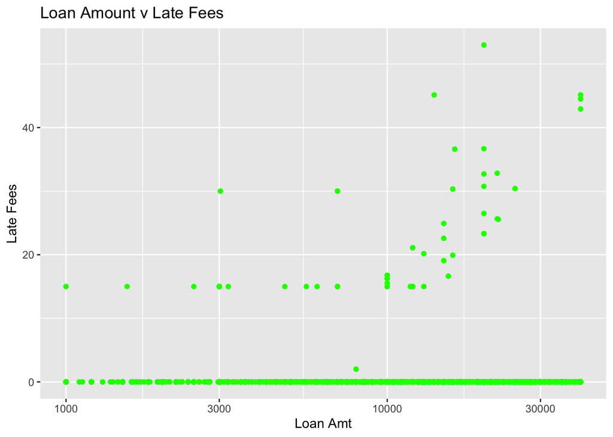

```r
loan_data %>% filter(loan_amount > 10) %>% ggplot(aes(x = loan_amount, y = paid_late_fees)) +geom_point(color = "green") +
  scale_x_log10() +
  labs(x = "Loan Amt", y = "Late Fees", title = "Loan Amount v Late Fees")
```

Here we saw the comparison using point graph of loan amount v late fees and loan amount v interest

Now let’s do the Machine Learning

Since we have to predict a numeric value we have to use a regression model

```r
lm_model <- lm(interest_rate~loan_data$annual_income,data=loan_data)
summary(lm_model)
```

```
##
## Call:
## lm(formula = interest_rate ~ loan_data$annual_income, data = loan_data)
##
## Residuals:
##     Min      1Q  Median      3Q     Max
## -7.6247 -3.3277 -0.7034  2.6595 18.7670
##
## Coefficients:
##                           Estimate Std. Error t value Pr(>|t|)
## (Intercept)              1.304e+01  7.865e-02  165.76   <2e-16 ***
## loan_data$annual_income -7.694e-06  7.688e-07  -10.01   <2e-16 ***
## ---
## Signif. codes:  0 '***' 0.001 '**' 0.01 '*' 0.05 '.' 0.1 ' ' 1
##
## Residual standard error: 4.976 on 9998 degrees of freedom
## Multiple R-squared:  0.009917,   Adjusted R-squared:  0.009818
## F-statistic: 100.1 on 1 and 9998 DF,  p-value: < 2.2e-16
```

The P-value is low and Rsquared is also low if we use income to predict the interest rate

Now let’s try multiple regression to predict interest rate using multiple variables

```r
multireg <- lm(interest_rate ~ annual_income + debt_to_income + delinq_2y,data=loan_data)
summary(multireg)
```

```
##
## Call:
## lm(formula = interest_rate ~ annual_income + debt_to_income +
##     delinq_2y, data = loan_data)
##
## Residuals:
##      Min       1Q   Median       3Q      Max
## -20.4070  -3.6973  -0.8243   2.6934  18.8003
##
## Coefficients:
##                  Estimate Std. Error t value Pr(>|t|)
## (Intercept)     1.193e+01  1.092e-01 109.184  < 2e-16 ***
## annual_income  -6.211e-06  7.735e-07  -8.030 1.08e-15 ***
## debt_to_income  4.325e-02  3.332e-03  12.981  < 2e-16 ***
## delinq_2y       7.157e-01  7.198e-02   9.943  < 2e-16 ***
## ---
## Signif. codes:  0 '***' 0.001 '**' 0.01 '*' 0.05 '.' 0.1 ' ' 1
##
## Residual standard error: 4.91 on 9972 degrees of freedom
##   (24 observations deleted due to missingness)
## Multiple R-squared:  0.03516,    Adjusted R-squared:  0.03487
## F-statistic: 121.1 on 3 and 9972 DF,  p-value: < 2.2e-16
```